# Impacts of storm and severe weather events in the United States

## Synopsis

Storms and other severe weather events can cause both public health and economic problems for communities and municipalities. Many severe events can result in fatalities, injuries, and property damage, and preventing such outcomes to the extent possible is a key concern. This project uses the U.S. National Oceanic and Atmospheric Administration’s (NOAA) storm database to study the impacts of major storms and weather events in the United States in population health and economy. This project can also be used to find the weather events that cause the highest number of casualties. It can also help in assessment of the property and crop damage during the weather events.

## Data Processing

The data was retrieved from the U.S. National Oceanic and Atmospheric Administration’s (NOAA) storm database.

```r
setwd("./StormData")
url <- "https://d396qusza40orc.cloudfront.net/repdata%2Fdata%2FStormData.csv.bz2"
if(!file.exists("StormData.bz2")){
  download.file(url,destfile = "StormData.bz2")
}
```

The Storm Data file is in a comma-separated-value file compressed via the bzip2 algorithm to reduce its size. There is also some documentation of the database available. Here you will find how some of the variables are constructed/defined.

- National Weather Service Storm Data [Documentation](https://d396qusza40orc.cloudfront.net/repdata%2Fpeer2_doc%2Fpd01016005curr.pdf)
- National Climatic Data Center Storm Events [FAQ](https://d396qusza40orc.cloudfront.net/repdata%2Fpeer2_doc%2FNCDC%20Storm%20Events-FAQ%20Page.pdf)

### Exploring the data

```r
stormData<- read.table("StormData.bz2", header = TRUE, sep = ",", stringsAsFactors = FALSE, na.strings="NA")
```

The column names of the data are as follows:

```r
names(stormData)
```

```
##  [1] "STATE__"    "BGN_DATE"   "BGN_TIME"   "TIME_ZONE"  "COUNTY"
##  [6] "COUNTYNAME" "STATE"      "EVTYPE"     "BGN_RANGE"  "BGN_AZI"
## [11] "BGN_LOCATI" "END_DATE"   "END_TIME"   "COUNTY_END" "COUNTYENDN"
## [16] "END_RANGE"  "END_AZI"    "END_LOCATI" "LENGTH"     "WIDTH"
## [21] "F"          "MAG"        "FATALITIES" "INJURIES"   "PROPDMG"
## [26] "PROPDMGEXP" "CROPDMG"    "CROPDMGEXP" "WFO"        "STATEOFFIC"
## [31] "ZONENAMES"  "LATITUDE"   "LONGITUDE"  "LATITUDE_E" "LONGITUDE_"
## [36] "REMARKS"    "REFNUM"
```

The dimension of the data is given by:

```r
dim(stormData)
```

```
## [1] 902297     37
```

### Subsetting the data

```r
# Load packages
library(dplyr)
library(tidyr)
library(lubridate)
library(ggplot2)
library(ggpubr)
library(knitr)
```

The events in the database have an different combination of random items. Some of them are as follows:

```r
head(unique(stormData$EVTYPE))
```

```
## [1] "TORNADO"               "TSTM WIND"             "HAIL"
## [4] "FREEZING RAIN"         "SNOW"                  "ICE STORM/FLASH FLOOD"
```

Now, these weather events are defined into eight unique categories namely, tornado, thunderstorm, flood, hurricane, freezing, rainfall, heat and fire. Then a dataframe is created containing the total casualties per eight events.

```r
df<-stormData
newData<-df %>%
  mutate(Events = as.character(EVTYPE)) %>%
  ### Selecting certain words from events column and giving a common name in a new column
  mutate(Event = ifelse(grepl("TORNADO", Events),"Tornado",
                     ifelse(grepl("Thunderstorm|Wind|THUNDERSTORM|WIND|TSTM|HAIL|hail|Hail|STORM",
                                  Events),"Thunderstorm",
                            ifelse(grepl("Flood|FLOOD|Drowning|DROWNING|DAM",Events),"Flood",
                                   ifelse(grepl("Hurricane|HURRICANE", Events), "Hurricane",
                                          ifelse(grepl("Freeze|FREEZE|Cold|COLD|Snow|SNOW|snow|Frost|
                                                       FROST|ICE|Ice|Icy",Events),"Freezing",
                                                 ifelse(grepl("RAIN|Rain|Precipitation|PRECIPITATION|
                                                              Mudslide|MUDSLIDE| Wet|wet|WET",
                                                              Events),"Rainfall",
                                                        ifelse(grepl("HEAT|Heat|DROUGHT|Drought|DRY",
                                                                     Events),"Heat",
                                                               ifelse(grepl("FIRE|Fire|WILD",Events),
                                                                      "Fire","Other"
                     ))))))))) %>%
  select(Event,FATALITIES,INJURIES,PROPDMG,CROPDMG)  %>%
  ### Group by events
  group_by(Event)  %>%
  ### Take sum of all fatalities, injuries and property damage for each event
  summarise(Fatalities = sum(FATALITIES,na.rm = T),Injuries = sum(INJURIES,na.rm = T),
            Property_Damage = sum(PROPDMG,na.rm = T),Crop_Damage = sum(CROPDMG,na.rm = T))
```

### Impact of severe weather events on population health

A subset consisting casualties information for each event was created. Then a barplot was plotted to demonstrate graphically the number of fatalities and injuries for each event.

```r
### Create a subset containing only data related to population health
popHealth <- gather(newData[-6,1:3],Type,Casualties,-Event)
```

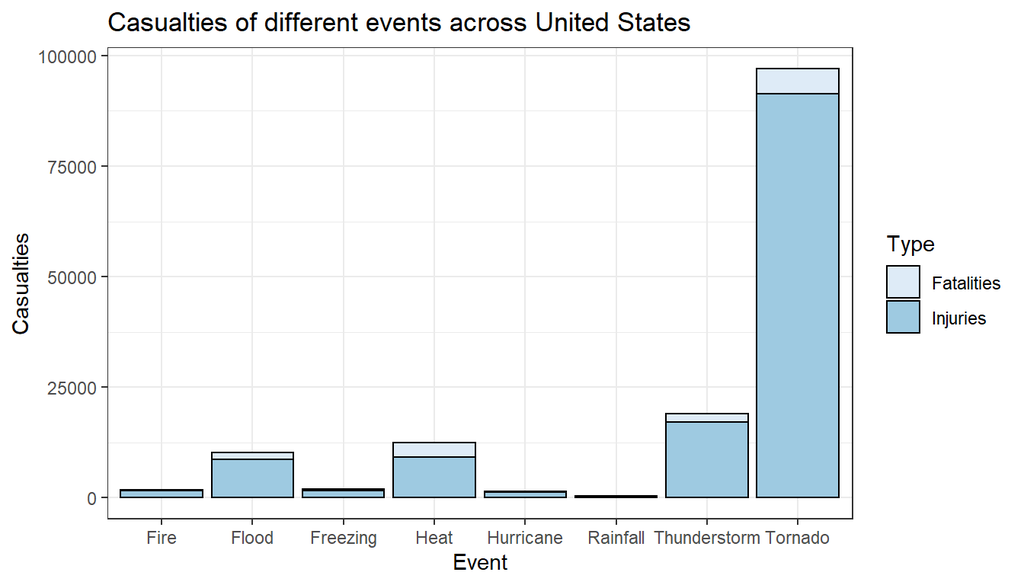

```r
### Plot a bargraph of casualties due to events in the US
g<- ggplot(popHealth,aes(x = Event,y = Casualties, fill = Type))
g + geom_bar(stat="identity", color="black") +
  scale_fill_brewer(palette="Blues")+
  labs(title = "Casualties of different events across United States") +
  theme_bw()
```

Here, it is clear that tornadoes cause the most casualties across the United States.

### Impact of severe weather events on the economy

A subset consisting property and crop damages information for each event was created. Then a barplot was plotted to demonstrate graphically the US dollars of property and crop damages for each event.

```r
# Plot a bargraph of property damage in the US
ecoDamage <- gather(newData[-6,c(1,4,5)],Type,Damages,-Event)
```

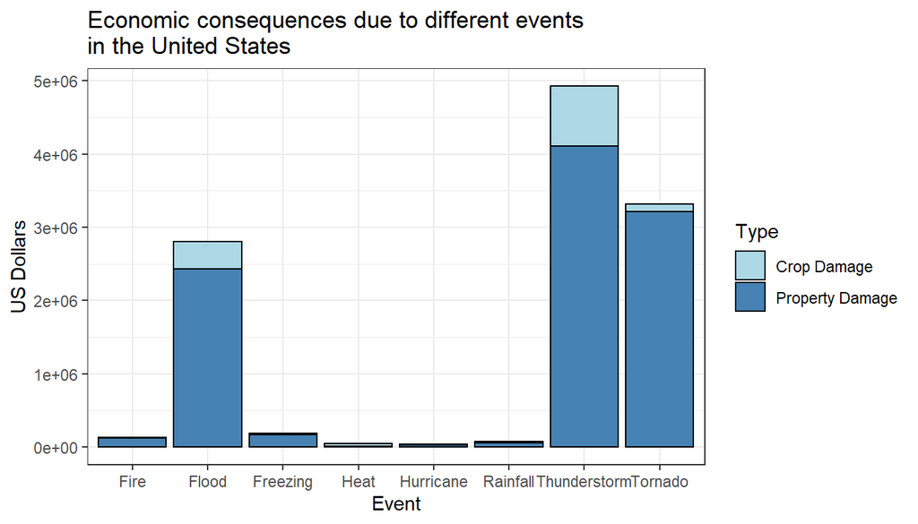

```r
g <- ggplot(ecoDamage,aes(x = Event,y = Damages, fill = Type))
g + geom_bar(stat="identity", color="black") +
  scale_fill_manual(values =  c("lightblue","steelblue"),labels=c("Crop Damage", "Property Damage"))+
  labs(y = "US Dollars") +
  labs(title = "Economic consequences due to different events\nin the United States") +
  theme(axis.title.x=element_text(hjust = 0.5,vjust = 0.5,angle = 45))+
  theme_bw()
```

### Impacts of weather events per year

The impacts that severe weather events can have on population health and economy can be illustrated by comparing the yearly casualties and damages from the events. This was done in a series of steps: - Adding a column containing year for the data

```r
df1<-stormData
df1$Year <- sapply(df1$BGN_DATE,function(x){
  (as.POSIXlt(mdy_hms(x))$year + 1900)
})
```

- Determining the total number of the casualties and damages per year

```r
datagroupedbyYear<-df1 %>%
  select(Year,FATALITIES,INJURIES,PROPDMG,CROPDMG) %>%
  group_by(Year) %>%
  summarise_all(sum,na.rm = T)
```

- Creating separate subsets of casualties and damages and combining into one dataframe

```r
# Create subsets per year
casualitiesgroupedbyYear <- gather(datagroupedbyYear[,1:3],Casualties,Number,-Year)
economygroupedbyYear <- gather(datagroupedbyYear[,c(1,4,5)],Damages,USD,-Year)
alldatabyYear <- merge(casualitiesgroupedbyYear,economygroupedbyYear,by = "Year")
```

- Plotting the casualties and economic damages

```r
cs <- ggplot(alldatabyYear,aes(x = Year,y = Number)) +
  geom_line(aes(color = Casualties),size = 1) +
  labs(title = "Casualties due to weather events\nacross the United States") +
  labs(y = "Number of casualties") +
  theme_bw() +
  theme(legend.position = "bottom") +
  theme(legend.title=element_blank())
```

```r
ec <- ggplot(alldatabyYear,aes(x = Year,y = USD)) +
  geom_line(aes(color = Damages),size = 1) +
  labs(title = "Economic consequences due to weather events\nacross the United States")  +
  labs(y = "U.S. Dollars") +
  theme_bw() +
  theme(legend.position = "bottom") +
  theme(legend.title=element_blank())
```

The impacts of weather events can be accessed by graphically determining casualties and economic damages by year. The figures below show that both casualties and economic damages have increased along time.

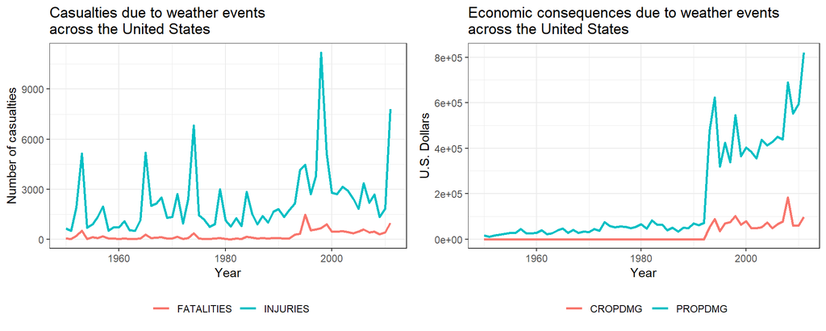

```r
ggarrange(cs, ec, ncol = 2, nrow = 1)
```